# geom_dotplot

Ethel Ruan

2017-01-20

# geom_dotplot

`geom_dotplot` **Dot plot**

## Usage

[output not shown]

## Description

In a dot plot, the width of a dot corresponds to the bin width (or maximum width, depending on the binning algorithm), and dots are stacked, with each dot representing one observation.

## Details

With dot-density binning, the bin positions are determined by the data and `binwidth`, which is the maximum width of each bin. See Wilkinson (1999) for details on the dot-density binning algorithm.

With histodot binning, the bins have fixed positions and fixed widths, much like a histogram.

## Aesthetics

`geom_dotplot` understands the following aesthetics (required aesthetics are in bold):

```
    x
    y
    alpha
    colour
    fill
```

## Computed variables

x center of each bin, if binaxis is “x”

y center of each bin, if binaxis is “x”

binwidth max width of each bin if method is “dotdensity”; width of each bin if method is “histodot”

count number of points in bin

ncount count, scaled to maximum of 1

density density of points in bin, scaled to integrate to 1, if method is “histodot”

ndensity density, scaled to maximum of 1, if method is “histodot”

## References

Wilkinson, L. (1999) Dot plots. The American Statistician, 53(3), 276

## Examples

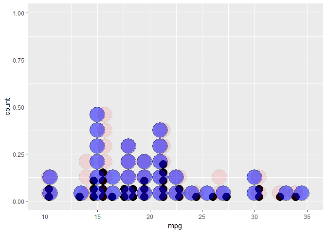

```r
library(ggplot2)
#`stat_bindot()` using `bins = 30`. Pick better value with `binwidth`.
ggplot(mtcars, aes(x = mpg)) +
  geom_dotplot() +
  geom_dotplot(binwidth = 1.5,fill = "red",alpha = 0.1) +
  #use fixed-width bins
  geom_dotplot(method="histodot", binwidth = 1.5,fill= "blue",alpha = 0.5)
```

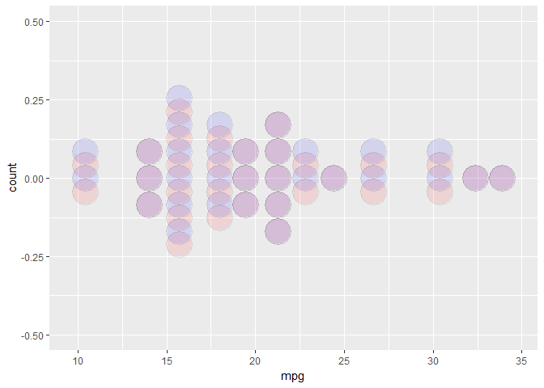

```r
ggplot(mtcars, aes(x = mpg)) +
  geom_dotplot(binwidth = 1.5, stackdir = "center",fill = "red",alpha = 0.1) +
  geom_dotplot(binwidth = 1.5, stackdir = "centerwhole",fill = "blue", alpha = 0.1)
```

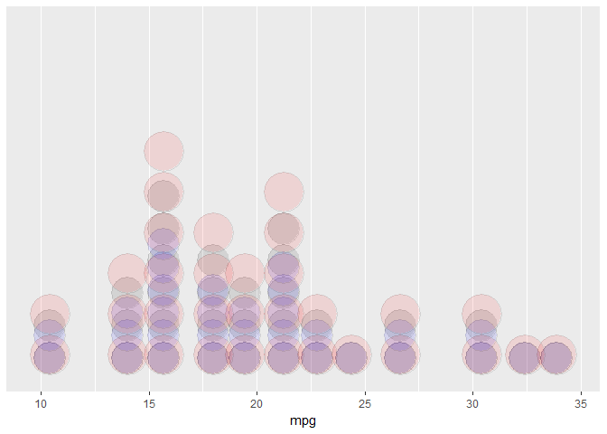

```r
  # y axis isn't really meaningful, so hide it
  ggplot(mtcars, aes(x = mpg)) + geom_dotplot(binwidth = 1.5,alpha= 0.1) +
  scale_y_continuous(NULL, breaks = NULL) +
  # Overlap dots vertically
  geom_dotplot(binwidth = 1.5, stackratio = .7,fill = "blue",alpha = 0.1) +
  # Expand dot diameter
  geom_dotplot(binwidth = 1.5, dotsize = 1.25,fill = "red",alpha= 0.1)
```

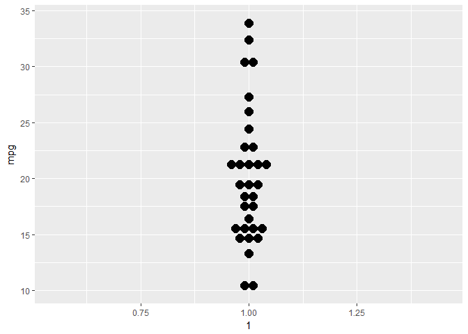

```r
# Examples with stacking along y axis instead of x
ggplot(mtcars, aes(x = 1, y = mpg)) +
  geom_dotplot(binaxis = "y", stackdir = "center")
```

`stat_bindot()` using `bins = 30`. Pick better value with `binwidth`.

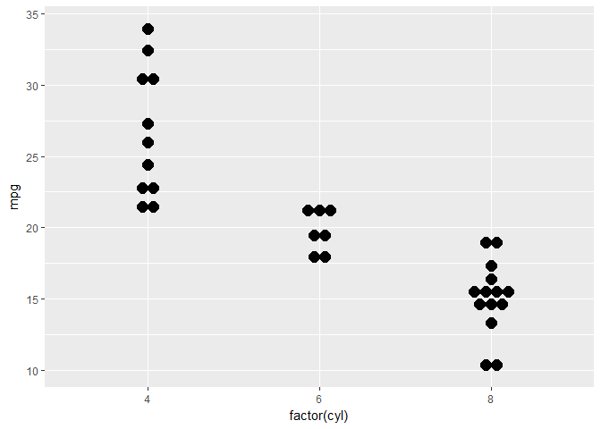

```r
ggplot(mtcars, aes(x = factor(cyl), y = mpg)) +
  geom_dotplot(binaxis = "y", stackdir = "center")
```

`stat_bindot()` using `bins = 30`. Pick better value with `binwidth`.

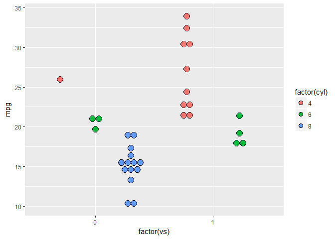

```r
ggplot(mtcars, aes(x = factor(vs), fill = factor(cyl), y = mpg)) +
  geom_dotplot(binaxis = "y", stackdir = "center", position = "dodge")
```

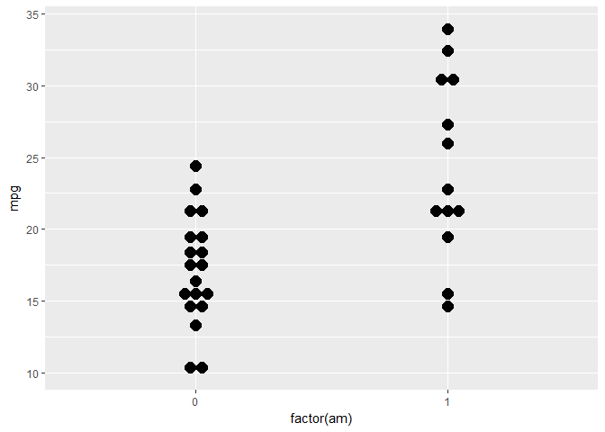

```r
# binpositions="all" ensures that the bins are aligned between groups
ggplot(mtcars, aes(x = factor(am), y = mpg)) +
  geom_dotplot(binaxis = "y", stackdir = "center", binpositions="all")
```

```r
# `stat_bindot()` using `bins = 30`. Pick better value with `binwidth`.
```

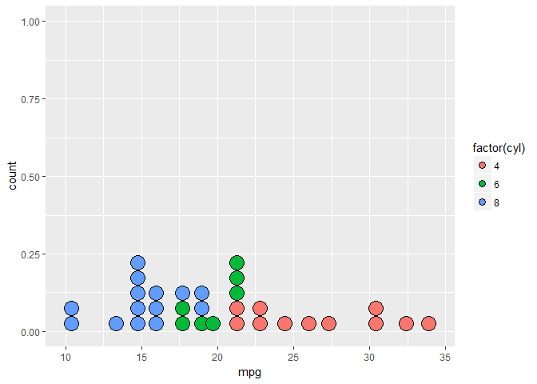

```r
# Stacking multiple groups, with different fill
ggplot(mtcars, aes(x = mpg, fill = factor(cyl))) +
  geom_dotplot(stackgroups = TRUE, binwidth = 1, binpositions = "all")
```

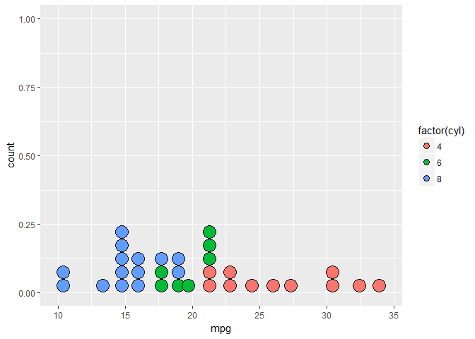

```r
# Stacking multiple groups, with different fill
ggplot(mtcars, aes(x = mpg, fill = factor(cyl))) +
  geom_dotplot(stackgroups = TRUE, binwidth = 1, binpositions = "all")
```

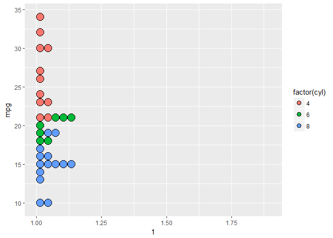

```r
ggplot(mtcars, aes(x = 1, y = mpg, fill = factor(cyl))) +
  geom_dotplot(binaxis = "y", stackgroups = TRUE, binwidth = 1, method = "histodot")
```